# 2 ## Example: healthy sleep

#### 2.0.4.3 HCP: example of bias, variance, and MSE

- In HCP data

```r
# Show what Bias and Variance mean in NSDUH data using simulations
nstudies = 100000

p = mean(hcp$healthySleep)

n = 100
phats = rep(NA, nstudies)
for(study in 1:nstudies){
  # random sample
  x = rbinom(n = n, prob = p, size=1)
  # estimate phat
  phats[study] = mean(x)
}

# mean of phat across the simulations
mean(phats)
```

```
## [1] 0.58863
```

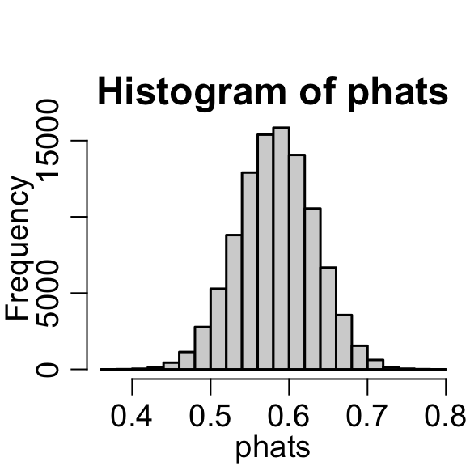

```r
hist(phats)
```

```r
# variance of phat across the simulations
var(phats)
```

```
## [1] 0.002424651
```

```r
# what the variance should be equal to
p * (1-p)/n
```

```
## [1] 0.002421282
```

### 2.0.5 Parameters, Estimators, Estimates

To reiterate:

- **Parameter** – Target unknown feature of a population (nonrandom)
- **Estimate** – Value computed from observed data to approximate the parameter (nonrandom)
- **Estimator** – A function of a random sample to approximate the parameter

In statistics, probability is used to define and describe the behavior of estimators.

- Often, the distribution of an estimator is makes it too hard to find the bias, variance, and MSE of the estimator.
- In this case, we use simulations to *estimate* the bias, variance, and MSE of an estimator.
- Important concepts for this session:
  - Simulations can be used to estimate the bias and variance when it is too hard to find mathematically.
  - Sometimes, the parameter of interest is not distributional parameter.

### 2.0.6 Another example: multiplexed immunofluorescence (mIF) microscopy

- mIF imaging uses antibody markers to identify protein in tissue samples.
- The protein Beta-catenin is known to be higher in tumor cells.

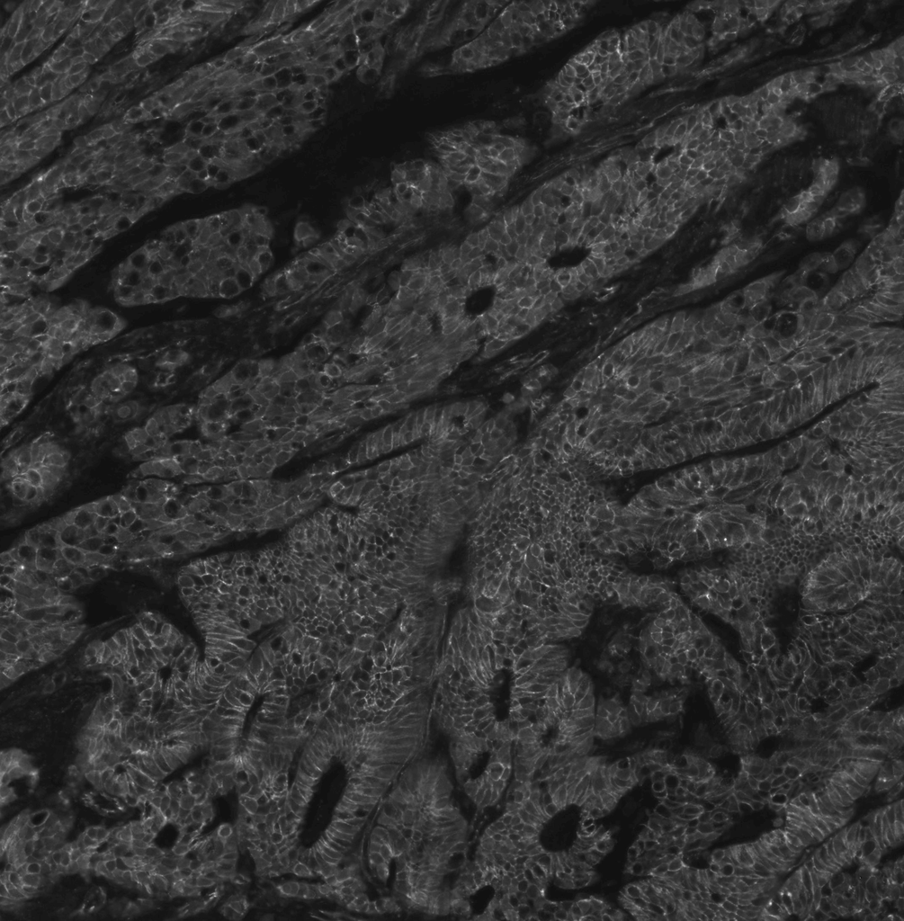

beta catenin image

### 2.0.7 mIF imaging in a statistical framework

Suppose we want to ask the question, “What is the mean concentration of Beta-catenin in the cells from a given tissue sample?”

1. What is my parameter of interest (target parameter)?
   - Mean cellular concentration of Beta-catenin $\mathbb{E}X_i$
2. What is my population of interest?
   - All possible cells from the given tumor (potentially)?
   - All possible cells from similar tumors?
3. What is a data point?
   - A single cell
4. What model can I use to describe how I get a data point?
   - That’s a good question. Here is the histogram of the data

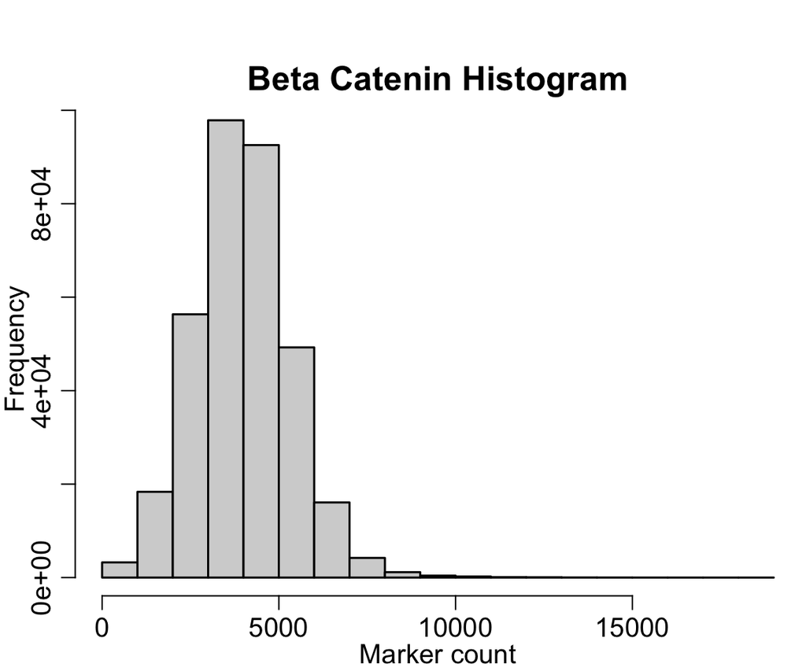

```r
bc = readRDS('../datasets/betaCatenin.rds')
hist(bc, main='Beta Catenin Histogram', xlab='Marker count')
```

+ The Beta-catenin concentration across cells could be modeled with a Gamma distribution.

### 2.0.8 A Gamma model for Beta-catenin concentration

- Previously, we defined the parameter of interest $p$ based on what we were interested in the sleep problem and it also happened to be the parameter of the Bernoulli distribution.
- In this example that is not the case.
- Let $X_i$ denote a randomly drawn cell from the tissue image.
- Assume $X_i \sim \text{Gamma}(\alpha, \beta)$.
- Let’s consider three parameters
  1. $\mathbb{E}X_i = \alpha/\beta$
  2. $\alpha$ (shape parameter)
  3. $\beta$ (rate parameter)

Let’s assess estimators for each of these parameters.

### 2.0.9 MxIF example: Estimators

I used method of moments (which you’ll learn in another class) to obtain estimators for these parameters. The estimators are
$$\begin{align*}
\hat \mu & = \bar X = n^{-1} \sum_{i=1}^n X_i \\
\tilde \alpha & = \frac{\bar X^2}{\left(\overline{X^2} - \bar X^2\right)} \\
\tilde \beta & = \frac{\bar X}{\left(\overline{X^2} - \bar X^2\right)}
\end{align*}$$

- $\tilde \alpha$ and $\tilde \beta$ are complicated functions of random variables involving ratios.
- It might be hard to find their bias. It will definitely be hard to find their variance.
- Instead, let’s use simulations to assess the bias, variance, and MSE of these estimators.

### 2.0.10 Concept of simulation study

- The bias, variance, and MSE are defined with respect to distribution of the test statistic across repeated samples of the data.
- If I can repeat the experiment in `R` multiple times, then I can see multiple random versions of the estimator.
- A simulation is an experiment to study what happens across experiments.

### 2.0.11 Simulation study

```r
set.seed(100)
# number simulation
nsim = 10000
# sample sizes
ns = c(10, 25, 50, 100, 200, 500)
# values of alpha to consider
alphas = c(0.5, 5)
# values of beta to consider
betas = c(0.25, 3)

# presults = data.frame(p=ps, biasmuHat = rep(NA, np), biassigmaSqHat=rep(NA, np), biassigmaSqHat2=rep(NA, np),
#                       varmuHat=rep(NA, np), varsigmaSqHat=rep(NA, np), varsigmaSqHat2=rep(NA, np))

presults = expand.grid(alpha = alphas, beta=betas, n=ns)
colNames = paste(rep(c('muHat', 'alphaTilde', 'betaTilde'), each=3),
                rep(c('Bias', 'Variance', 'MSE'), 3))
presults[, colNames ] = NA

alphaind = 1; betaind = 2; nind = 3
# loops through the parameter values
for(alphaind in 1:length(alphas) ){
  for(betaind in 1:length(betas)){

      # data generating distribution parameters (for the gamma distribution)
      alpha = alphas[alphaind]
      beta = betas[betaind]

    for(nind in 1:length(ns)){
      # get n for this simulation setting
      n = ns[nind]
      cat(which(presults$n==n & presults$alpha==alpha & presults$beta == beta), '\t')

      # loops through the simulations
      # each simulation is one realization of the world
      results = data.frame(muHat = rep(NA, nsim), alphaTilde=rep(NA, nsim), betaTilde=rep(NA, nsim) )
      for(sim in 1:nsim){

        # sample a data set of size n from some random variable
        x = rgamma(n, shape=alpha, rate=beta)

        # compute estimators
        muHat = mean(x)
        alphaTilde = muHat^2 / var(x)
        betaTilde = muHat / var(x)
        #sigmaSqHat = sum((x-mean(x))^2)/(length(x)-1)

        results[sim, c('muHat', 'alphaTilde', 'betaTilde') ] = c(muHat, alphaTilde, betaTilde)
      } # end of the nsim loop

      # saving the results for each value of p
      #presults[pind, c('biasmuHat', 'biassigmaSqHat', 'biasSigmaSqHat2')] = colMeans(results) - c(p, p*(1-p), p*(1-p))
      #presults[pind, c('varmuHat', 'varsigmaSqHat', 'varSigmaSqHat2')] = diag(var(results))

      # Bias variance MSE for muHat
      presults[ which(presults$n==n & presults$alpha==alpha & presults$beta == beta), c('muHat Bias', 'muHat Variance', 'muHat MSE')] = c(mean(results$muHat) - alpha/beta,
                                                                var(results$muHat),
                                                                (mean(results$muHat) - alpha/beta)^2 + var(results$muHat) )
      presults[ which(presults$n==n & presults$alpha==alpha & presults$beta == beta), c('alphaTilde Bias', 'alphaTilde Variance', 'alphaTilde MSE')] = c(mean(results$alphaTilde) - alpha,
                                                                var(results$alphaTilde),
                                                                (mean(results$alphaTilde) - alpha)^2 + var(results$alphaTilde) )
      presults[ which(presults$n==n & presults$alpha==alpha & presults$beta == beta), c('betaTilde Bias', 'betaTilde Variance', 'betaTilde MSE')] = c(mean(results$betaTilde) - beta,
                                                                var(results$betaTilde),
                                                                (mean(results$betaTilde) - beta)^2 + var(results$betaTilde) )
    } # loop through ns
  } # loop through the betas
} # loop through the alphas
```

```
## 1    5   9   13  17  21  3   7   11  15  19  23  2   6   10  14  18  22  4   8   12  16  20  24
```

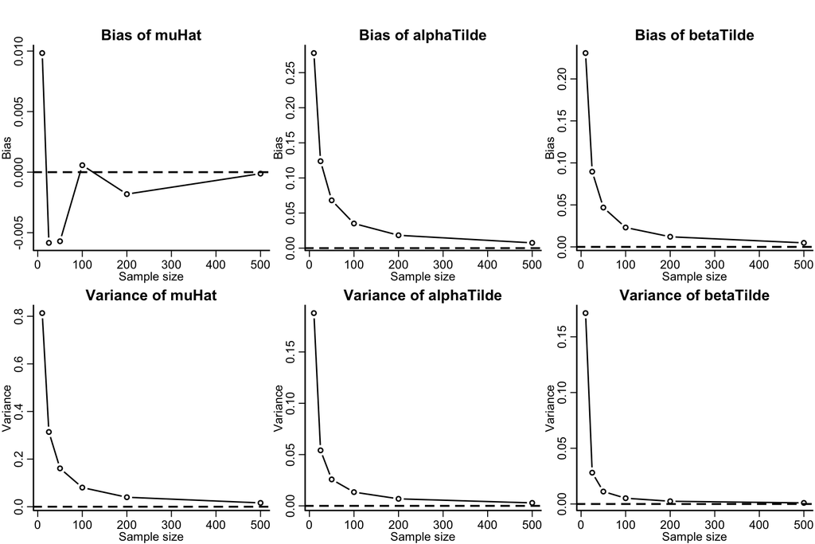

```r
subres = presults[ presults$alpha==0.5 & presults$beta ==0.25,]
layout(matrix(1:6, nrow=2, byrow=TRUE))

# Bias plots
plot(subres$n, subres[, 'muHat Bias'], xlab='Sample size', ylab='Bias', main='Bias of muHat', type='b')
abline(h=0, lty=2, lwd=2)
plot(subres$n, subres[, 'alphaTilde Bias'], xlab='Sample size', ylab='Bias', main='Bias of alphaTilde', type='b')
abline(h=0, lty=2, lwd=2)
plot(subres$n, subres[, 'betaTilde Bias'], xlab='Sample size', ylab='Bias', main='Bias of betaTilde', type='b')
abline(h=0, lty=2, lwd=2)
plot(subres$n, subres[, 'muHat Variance'], xlab='Sample size', ylab='Variance', main='Variance of muHat', type='b')
abline(h=0, lty=2, lwd=2)
plot(subres$n, subres[, 'alphaTilde Variance'], xlab='Sample size', ylab='Variance', main='Variance of alphaTilde', type='b')
abline(h=0, lty=2, lwd=2)
plot(subres$n, subres[, 'betaTilde Variance'], xlab='Sample size', ylab='Variance', main='Variance of betaTilde', type='b')
abline(h=0, lty=2, lwd=2)
```

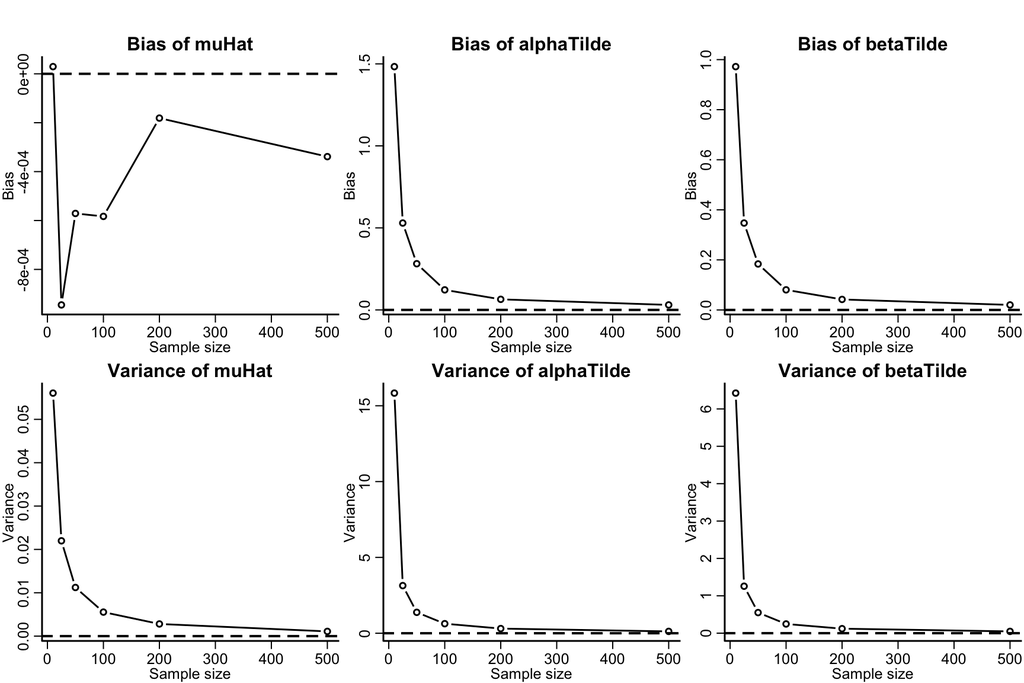

```r
subres = presults[ presults$alpha==5 & presults$beta ==3,]
layout(matrix(1:6, nrow=2, byrow=TRUE))

# Bias plots
plot(subres$n, subres[, 'muHat Bias'], xlab='Sample size', ylab='Bias', main='Bias of muHat', type='b')
abline(h=0, lty=2, lwd=2)
plot(subres$n, subres[, 'alphaTilde Bias'], xlab='Sample size', ylab='Bias', main='Bias of alphaTilde', type='b')
abline(h=0, lty=2, lwd=2)
plot(subres$n, subres[, 'betaTilde Bias'], xlab='Sample size', ylab='Bias', main='Bias of betaTilde', type='b')
abline(h=0, lty=2, lwd=2)
plot(subres$n, subres[, 'muHat Variance'], xlab='Sample size', ylab='Variance', main='Variance of muHat', type='b')
abline(h=0, lty=2, lwd=2)
plot(subres$n, subres[, 'alphaTilde Variance'], xlab='Sample size', ylab='Variance', main='Variance of alphaTilde', type='b')
abline(h=0, lty=2, lwd=2)
plot(subres$n, subres[, 'betaTilde Variance'], xlab='Sample size', ylab='Variance', main='Variance of betaTilde', type='b')
abline(h=0, lty=2, lwd=2)
```

- Percent bias instead of raw bias

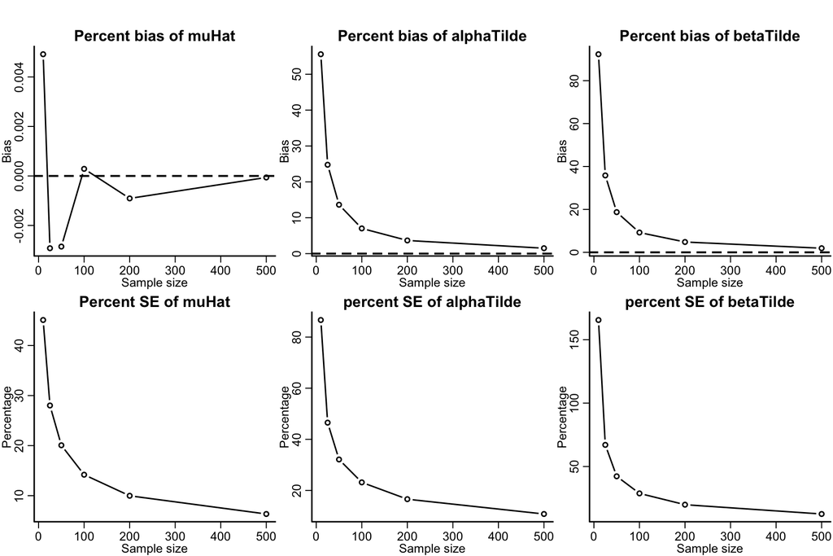

```r
subres = presults[ presults$alpha==0.5 & presults$beta ==0.25,]
layout(matrix(1:6, nrow=2, byrow=TRUE))

# Bias plots
plot(subres$n, subres[, 'muHat Bias']/(subres[,'alpha']/subres[,'beta']), xlab='Sample size', ylab='Bias', main='Percent bias of muHat', type='b')
abline(h=0, lty=2, lwd=2)
plot(subres$n, subres[, 'alphaTilde Bias']/subres[,'alpha']*100, xlab='Sample size', ylab='Bias', main='Percent bias of alphaTilde', type='b')
abline(h=0, lty=2, lwd=2)
plot(subres$n, subres[, 'betaTilde Bias']/subres[,'beta']*100, xlab='Sample size', ylab='Bias', main='Percent bias of betaTilde', type='b')
abline(h=0, lty=2, lwd=2)
plot(subres$n, sqrt(subres[, 'muHat Variance'])/(subres[,'alpha']/subres[,'beta'])*100, xlab='Sample size', ylab='Percentage', main='Percent SE of muHat', type='b')
abline(h=0, lty=2, lwd=2)
plot(subres$n, sqrt(subres[, 'alphaTilde Variance'])/subres[,'alpha']*100, xlab='Sample size', ylab='Percentage', main='percent SE of alphaTilde', type='b')
abline(h=0, lty=2, lwd=2)
plot(subres$n, sqrt(subres[, 'betaTilde Variance'])/subres[,'beta']*100, xlab='Sample size', ylab='Percentage', main='percent SE of betaTilde', type='b')
abline(h=0, lty=2, lwd=2)
```

### 2.0.12 Assessing estimators in the homework

- I left more interesting problems for you to do in the homework.
- There, you will compare two estimators for the same parameter, and pick which one you think is better.

### 2.0.13 MxIF example: Estimate

The estimates in the real data are $\hat\mu=$`3985.4`, $\tilde\alpha=$`8.7`, and $\tilde\beta=$`0.002`.

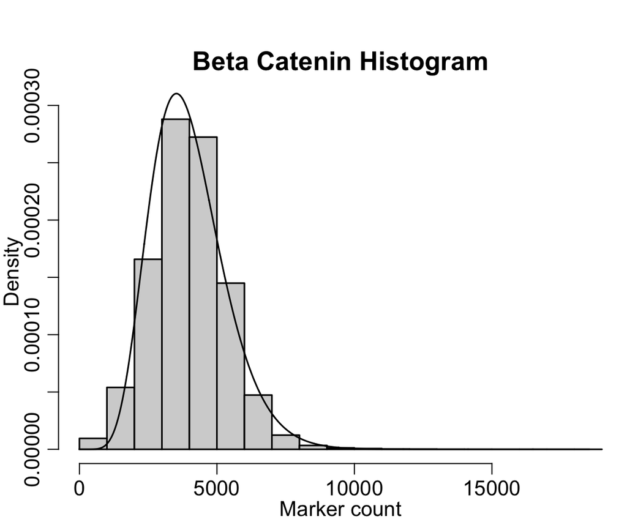

```r
bc = readRDS('../datasets/betaCatenin.rds')
alphaTilde = mean(bc)^2/var(bc)
betaTilde = mean(bc)/var(bc)


x = seq(from=min(bc), to=max(bc), length.out=1000)
y = dgamma(x, shape=alphaTilde, rate=betaTilde)
hist(bc, main='Beta Catenin Histogram', freq=FALSE, xlab='Marker count', ylim=range(y))
points(x, y, type='l')
```